# Judgement ③ — canonicalisation: do models merge synonyms correctly?

Canonicalisation is the merge/split decision — should `"LDN"` and `"low dose naltrexone"` collapse to one drug? Unusually for these judgements, we have a **real gold**: the alias surface-forms come from the ① alias-generation run, so we know each one's true drug. Every model was given the deduped alias list and asked to group synonyms; we score its grouping against the true drug grouping (Adjusted Rand Index + pairwise merge precision/recall) and check how much the models agree with each other.

*(loaded — 192 aliases over 16 drugs, 12 models)*

## 1. Canonicalisation accuracy per model

Adjusted Rand Index (grouping vs the true drug grouping; 1.0 = perfect, 0 = chance) and the underlying merge precision/recall on alias pairs.

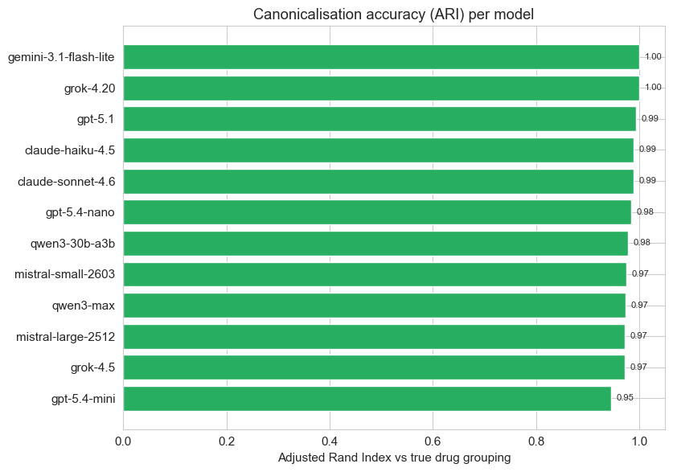

**Per-model: ARI + pairwise merge precision / recall / F1**

| model | ARI | merge precision | merge recall | merge F1 |
| --- | --- | --- | --- | --- |
| gemini-3.1-flash-lite | 1.00 | 100% | 100% | 100% |
| grok-4.20 | 1.00 | 100% | 100% | 100% |
| gpt-5.1 | 0.99 | 100% | 99% | 99% |
| claude-haiku-4.5 | 0.99 | 100% | 98% | 99% |
| claude-sonnet-4.6 | 0.99 | 100% | 98% | 99% |
| gpt-5.4-nano | 0.98 | 100% | 97% | 99% |
| qwen3-30b-a3b | 0.98 | 100% | 96% | 98% |
| mistral-small-2603 | 0.97 | 100% | 95% | 98% |
| qwen3-max | 0.97 | 100% | 95% | 97% |
| mistral-large-2512 | 0.97 | 100% | 95% | 97% |
| grok-4.5 | 0.97 | 100% | 95% | 97% |
| gpt-5.4-mini | 0.95 | 100% | 90% | 95% |

**Median ARI 0.98, median merge-recall 97%.** The dominant error mode is under-merging — a model leaves `"famo"`, `"pepcid"`, `"famotidine hcl"` in separate groups (recall < precision). Splitting distinct drugs apart (precision) is rarely the problem; **collapsing all the surface variants of one drug is the hard part**, and it's where models differ most.

## 2. Do the models agree with each other on the merges?

**Mean pairwise ARI between models: 0.97** (vs mean 0.98 against the gold). Models agree with *each other* about as much as with the truth — canonicalisation is fairly determined (there's a right answer and capable models mostly find it), so cross-model divergence here is a reliable outlier signal, not underdetermination. A model far below the pack is genuinely worse at merging, not just idiosyncratic.

## 3. What gets mis-merged

**Aliases most often left un-merged from their drug (across models)**

| alias | true drug | models that split it off |
| --- | --- | --- |
| ldn | naltrexone | 6/12 |
| low dose naltrexone | naltrexone | 6/12 |
| zyrtec-d | cetirizine | 4/12 |
| gaba | gabapentin | 4/12 |
| colchicin | colchicine | 2/12 |
| allegra d | fexofenadine | 2/12 |
| famotidin | famotidine | 1/12 |
| famotidine hcl | famotidine | 1/12 |
| famotadine | famotidine | 1/12 |
| famotidine hydrochloride | famotidine | 1/12 |
| famotidene | famotidine | 1/12 |
| famotidne | famotidine | 1/12 |

## 4. Verdict

- **Canonicalisation is one of the more accurate judgements** — median ARI 0.98 vs the true drug grouping; the merge decision has a right answer and capable models mostly get it.

- **Under-merging is the failure mode** — models leave synonym/typo/dose variants in separate groups (recall < precision). Splitting distinct drugs apart is rare.

- **Cross-model agreement ≈ agreement-with-gold**, so this judgement is *determined* — a model well below the pack is a real outlier to drop, not just a different-but-valid style (unlike the subjective judgements).

- **Cheap win:** front the LLM merge with deterministic normalisation + RxNorm lookup (covers the ~38% RxNorm-scoreable names for free); reserve the model for the genuinely ambiguous merges.

## Limitations

- **Gold is the 6-target-drug alias space** (plus incidental drugs from the ① run) — real corpus canonicalisation faces peptides, supplements, and drug *classes* that RxNorm can't score; this measures the cleaner drug-synonym case.
- **Merge quality measured on alias pairs / ARI** — a single mis-grouped high-frequency alias moves the number; read the tier, not the 2nd decimal.
- **One canonicalisation call per model** (no repeats) — no within-model variability here.
- Measures a normalisation step's correctness, not any treatment effect. Not medical advice.

**Provenance**

| item | value |
| --- | --- |
| gold | j1_alias_runs (known drug->alias groupings) |
| aliases | 192 |
| drugs | 16 |
| models | 12 |
| metric | Adjusted Rand Index + pairwise merge P/R/F1 |
| skill | research-assistant v2 |

Measures the correctness of a normalisation step, not treatment effects. Not medical advice.